# Zelimhan Gudiev HW5

2022-11-04

# Лабораторная работа 3 по дисциплине “Data Mining”

Ассоциативное моделирование

Используются данные о пассажирах «Титаника». Введите данные в рабочее пространство. (в этом случае Данные «Титаник» содержатся в базовом наборе примеров R, и это делать необязательно) Выведите общие сведения о данных. Укажите, какие имеются параметры, какого они вида, и какие возможные значения принимают. Сделайте несколько (4-5) предположений о том, какие закономерности можно найти в этих данных. Для каждого предположения сформулируйте, как должен быть поставлен исследовательский (аналитический) вопрос о его выяснении.

```r
str(Titanic)
```

```
##  'table' num [1:4, 1:2, 1:2, 1:2] 0 0 35 0 0 0 17 0 118 154 ...
##  - attr(*, "dimnames")=List of 4
##   ..$ Class   : chr [1:4] "1st" "2nd" "3rd" "Crew"
##   ..$ Sex     : chr [1:2] "Male" "Female"
##   ..$ Age     : chr [1:2] "Child" "Adult"
##   ..$ Survived: chr [1:2] "No" "Yes"
```

**В данном наборе данных можно исследовать как влияли пол, возраст и пассажирский класс на выживаемость пассажиров.**  
3. Переведите данные в формат фрейма.

```r
df<- as.data.frame(Titanic)
```

4. Создайте чистую таблицу данных “titanic.raw”, создав заголовки из исходных данных, и затем переместив исходные данные в эту таблицу. Проверьте, сколько наблюдений и параметров содержит этот файл (dim())? Рассматриваются ли категориальные переменные действительно как категориальные? Обратите внимание, что в новых данных категориальным переменным также присвоены числовые кодировки для возможных значений. Сделайте общие выводы о наблюдениях в данных (summary).

```r
titanic.raw <- NULL
for(i in 1:4) {titanic.raw <- cbind(titanic.raw, rep(as.character(df[,i]), df$Freq))}
titanic.raw <- as.data.frame(titanic.raw)
names(titanic.raw) <- names(df)[1:4]
dim(titanic.raw)
```

```
## [1] 2201    4
```

```r
summary(titanic.raw)
```

```
##     Class               Sex                Age              Survived
##  Length:2201        Length:2201        Length:2201        Length:2201
##  Class :character   Class :character   Class :character   Class :character
##  Mode  :character   Mode  :character   Mode  :character   Mode  :character
```

Присвоить имена колонкам можно командой (в данном случае колонки уже озаглавлены, и команда повторяет эти названия)

```r
names(titanic.raw)<-c("Class", "Sex", "Age", "Survived")
```

5. Выполните поиск ассоциативных закономерностей. Сколько всего закономерностей вы получили? Приведите полученные закономерности в виде списка или таблицы. Приведите несколько ассоциативных правил (5-7), представляющих исследовательский интерес. Приведите несколько ассоциативных правил (3-4), которые не имеют содержательного смысла.

```r
library(arules)
rules.all<-apriori(titanic.raw)
```

```
## Apriori
##
## Parameter specification:
##  confidence minval smax arem  aval originalSupport maxtime support minlen
##         0.8    0.1    1 none FALSE            TRUE       5     0.1      1
##  maxlen target  ext
##      10  rules TRUE
##
## Algorithmic control:
##  filter tree heap memopt load sort verbose
##     0.1 TRUE TRUE  FALSE TRUE    2    TRUE
##
## Absolute minimum support count: 220
##
## set item appearances ...[0 item(s)] done [0.00s].
## set transactions ...[10 item(s), 2201 transaction(s)] done [0.00s].
## sorting and recoding items ... [9 item(s)] done [0.00s].
## creating transaction tree ... done [0.00s].
## checking subsets of size 1 2 3 4 done [0.00s].
## writing ... [27 rule(s)] done [0.00s].
## creating S4 object  ... done [0.00s].
```

```r
rules.all
```

```
## set of 27 rules
```

```r
inspect(rules.all)
```

```
##      lhs                                     rhs           support   confidence
## [1]  {}                                   => {Age=Adult}   0.9504771 0.9504771
## [2]  {Class=2nd}                          => {Age=Adult}   0.1185825 0.9157895
## [3]  {Class=1st}                          => {Age=Adult}   0.1449341 0.9815385
## [4]  {Sex=Female}                         => {Age=Adult}   0.1930940 0.9042553
## [5]  {Class=3rd}                          => {Age=Adult}   0.2848705 0.8881020
## [6]  {Survived=Yes}                       => {Age=Adult}   0.2971377 0.9198312
## [7]  {Class=Crew}                         => {Sex=Male}    0.3916402 0.9740113
## [8]  {Class=Crew}                         => {Age=Adult}   0.4020900 1.0000000
## [9]  {Survived=No}                        => {Sex=Male}    0.6197183 0.9154362
## [10] {Survived=No}                        => {Age=Adult}   0.6533394 0.9651007
## [11] {Sex=Male}                           => {Age=Adult}   0.7573830 0.9630272
## [12] {Sex=Female, Survived=Yes}           => {Age=Adult}   0.1435711 0.9186047
## [13] {Class=3rd, Sex=Male}                => {Survived=No} 0.1917310 0.8274510
## [14] {Class=3rd, Survived=No}             => {Age=Adult}   0.2162653 0.9015152
```

[output cut: 41 more lines]

6. Выполните ассоциативный анализ для поиска закономерностей, характеризующих только выживаемость, и отсортируйте их по убыванию критерия интересности (lift). Сколько было получено правил? Приведите полученные правила в виде списка или таблицы.

```r
rules <- apriori(titanic.raw, control = list(verbose=F),
                 parameter = list(minlen=2, supp=0.005, conf=0.8),
                 appearance = list(rhs=c("Survived=No", "Survived=Yes"),
                                   default="lhs"))
quality(rules) <- round(quality(rules), digits=3)
rules.sorted <- sort(rules, by="lift")
inspect(rules.sorted)
```

```
##      lhs                                    rhs            support confidence
## [1]  {Class=2nd, Age=Child}              => {Survived=Yes} 0.011   1.000
## [2]  {Class=2nd, Sex=Female, Age=Child}  => {Survived=Yes} 0.006   1.000
## [3]  {Class=1st, Sex=Female}             => {Survived=Yes} 0.064   0.972
## [4]  {Class=1st, Sex=Female, Age=Adult}  => {Survived=Yes} 0.064   0.972
## [5]  {Class=2nd, Sex=Female}             => {Survived=Yes} 0.042   0.877
## [6]  {Class=Crew, Sex=Female}            => {Survived=Yes} 0.009   0.870
## [7]  {Class=Crew, Sex=Female, Age=Adult} => {Survived=Yes} 0.009   0.870
## [8]  {Class=2nd, Sex=Female, Age=Adult}  => {Survived=Yes} 0.036   0.860
## [9]  {Class=2nd, Sex=Male, Age=Adult}    => {Survived=No}  0.070   0.917
## [10] {Class=2nd, Sex=Male}               => {Survived=No}  0.070   0.860
## [11] {Class=3rd, Sex=Male, Age=Adult}    => {Survived=No}  0.176   0.838
## [12] {Class=3rd, Sex=Male}               => {Survived=No}  0.192   0.827
##      coverage lift  count
## [1]  0.011    3.096  24
## [2]  0.006    3.096  13
## [3]  0.066    3.010 141
## [4]  0.065    3.010 140
## [5]  0.048    2.716  93
## [6]  0.010    2.692  20
## [7]  0.010    2.692  20
## [8]  0.042    2.663  80
## [9]  0.076    1.354 154
## [10] 0.081    1.271 154
## [11] 0.210    1.237 387
## [12] 0.232    1.222 422
```

7. Из полученных правил ассоциации найдите три пары закономерностей, из которых одна является превосходящей по отношению к другой, и, как следствие, излишней, проведя математическую проверку для выявления таких правил (является ли одно множество подмножеством другого). Опишите эти правила, указав, что конкретно является не предоставляет дополнительной информации для каждого излишнего правила. (Определение. Излишним признается правило, которое является более общим по отношению к другому, и имеет такой же либо более низкий критерий подъема (lift). Например, правило 2 излишне по отношению к правилу 1, поскольку, согласно правилу 1, все дети из второго класса выжили. Этот пример в отчете о лабораторной использовать уже нельзя ☺ )

```r
subset.matrix <- is.subset(rules.sorted, rules.sorted)
# subset.matrix[lower.tri(subset.matrix, diag=T)] <- NA
redundant <- colSums(subset.matrix, na.rm=T)>1
which(!redundant)
```

```
##   {Class=2nd,Age=Child,Survived=Yes}  {Class=1st,Sex=Female,Survived=Yes}
##                                    1                                    3
##  {Class=2nd,Sex=Female,Survived=Yes} {Class=Crew,Sex=Female,Survived=Yes}
##                                    5                                    6
##     {Class=2nd,Sex=Male,Survived=No}     {Class=3rd,Sex=Male,Survived=No}
##                                   10                                   12
```

```r
rules.pruned<-rules.sorted[!redundant]
inspect(rules.pruned)
```

```
##     lhs                         rhs            support confidence coverage
## [1] {Class=2nd, Age=Child}   => {Survived=Yes} 0.011   1.000      0.011
## [2] {Class=1st, Sex=Female}  => {Survived=Yes} 0.064   0.972      0.066
## [3] {Class=2nd, Sex=Female}  => {Survived=Yes} 0.042   0.877      0.048
## [4] {Class=Crew, Sex=Female} => {Survived=Yes} 0.009   0.870      0.010
## [5] {Class=2nd, Sex=Male}    => {Survived=No}  0.070   0.860      0.081
## [6] {Class=3rd, Sex=Male}    => {Survived=No}  0.192   0.827      0.232
##     lift  count
## [1] 3.096  24
## [2] 3.010 141
## [3] 2.716  93
## [4] 2.692  20
## [5] 1.271 154
## [6] 1.222 422
```

9. Интерпретируйте оставшиеся правила на основе их содержательного значения либо здравого смысла, с учетом достоверности. (Например, правило 1 имеет уровень достоверности 1.0 и подъем 3.0, и интерпретируется как «все дети из класса 2 выжили». В то же время, правил по детям из 1 и 3 классов нет. Как следствие, можно неверно интерпретировать правило 1 как то, что дети 2 класса имели больший шанс на выживание, однако, правило всего лишь утверждает, что все дети 2 класса выжили, но не содержит информации о детях других классов, поэтому необходимо получить подобную информацию отдельно – см. задание 10. )
10. Проведите ассоциативный анализ выживших по 1-3 классам на основе возрастов «ребенок» и «взрослый», исключая прочую информацию:

```r
rules <- apriori(titanic.raw,
                 parameter=list(minlen=3, supp=0.002, conf=0.2),
                 appearance=list(rhs=c("Survived=No", "Survived=Yes"),
                                 lhs=c("Class=1st", "Class=2nd", "Class=3rd", "Age=Child", "Age=Adult"),
                                 default="none"),
                 control=list(verbose=F))
inspect(rules)
```

```
##      lhs                       rhs            support     confidence
## [1]  {Class=2nd, Age=Child} => {Survived=Yes} 0.010904134 1.0000000
## [2]  {Class=1st, Age=Child} => {Survived=Yes} 0.002726034 1.0000000
## [3]  {Class=3rd, Age=Child} => {Survived=Yes} 0.012267151 0.3417722
## [4]  {Class=3rd, Age=Child} => {Survived=No}  0.023625625 0.6582278
## [5]  {Class=2nd, Age=Adult} => {Survived=Yes} 0.042707860 0.3601533
## [6]  {Class=2nd, Age=Adult} => {Survived=No}  0.075874602 0.6398467
## [7]  {Class=1st, Age=Adult} => {Survived=Yes} 0.089504771 0.6175549
## [8]  {Class=1st, Age=Adult} => {Survived=No}  0.055429350 0.3824451
## [9]  {Class=3rd, Age=Adult} => {Survived=Yes} 0.068605179 0.2408293
## [10] {Class=3rd, Age=Adult} => {Survived=No}  0.216265334 0.7591707
##      coverage    lift      count
## [1]  0.010904134 3.0956399  24
## [2]  0.002726034 3.0956399   6
## [3]  0.035892776 1.0580035  27
## [4]  0.035892776 0.9723218  52
## [5]  0.118582463 1.1149048  94
## [6]  0.118582463 0.9451696 167
## [7]  0.144934121 1.9117275 197
## [8]  0.144934121 0.5649408 122
## [9]  0.284870513 0.7455209 151
## [10] 0.284870513 1.1214326 476
```

Ответьте на вопросы:  
А) отличается ли выживаемость детей из 1 класса от ехавших 2-м? **- Нет.**  
Б) какой процент детей, ехавших первым классом, выжили? **- 100%**  
В) какой процент детей, ехавших третьим классом, выжили? **- 34.17%**  
Г) какой процент взрослых, ехавших вторым классом, выжили? Сопоставьте это значение с числом в вопросе (В) **- 36.01%, почти на два процента больше чем выжило детей из 3-го класса**  
Д) какой процент взрослых, ехавших первым классом, выжили? Сопоставьте это значение с числами в вопросах (В) и (Г) **- 61.75%, почти в два раза больше чем детей из 3-го класса и взрослых из 2-го.**

11. Представьте данные в виде графика ассоциаций. Приведите 2-3 примера ассоциативных правил из графика. Можно ли утверждать обратное для этих правил? Для каких можно, и для каких – нельзя? Обоснуйте ваш ответ.

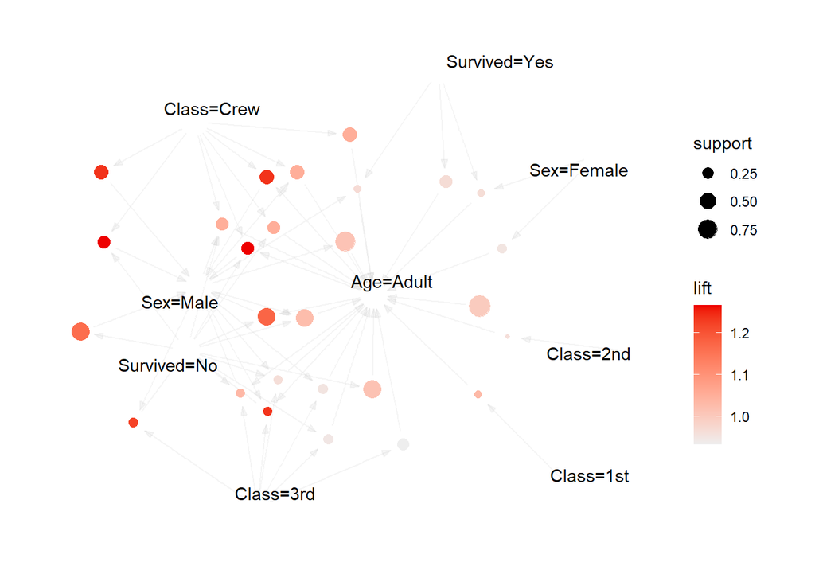

```r
plot(rules.all, method="graph")
```

или

[output not shown]

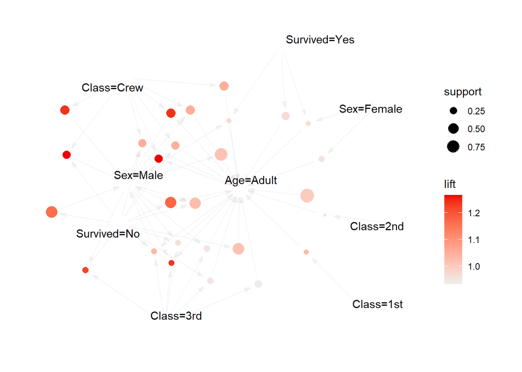

```r
plot(rules.all, method="graph", control=list(type="itemsets"))
```